# Session 08 Tree-Based Models | Exercise & Solution

[**CCMVI2085U Machine Learning for Predictive Analytics in Business @ CBS ISUP 2020**](https://kursuskatalog.cbs.dk/2019-2020/KAN-CCMVI2085U.aspx?lang=en-GB)

Course coordinator: [Bowei Chen](https://boweichen.github.io/) | Email: bc.acc@cbs.dk

# Table of Contents

```python
%load_ext nb_black
```

## Project: Hotel event prediction

Let's revisit this holiday event business project!

Suppose we are analysts working with a client – a large seaside resort company whose business is to provide affordable holiday family fun activities and entertainments. The company would like us to develop a model which can recommend this summer’s events (e.g., spa, shows, and outdoor activities) to the booked customers (i.e., booked flats). Our goal is to develop a data-driven model which can segment customers from the last summer’s data and use it to recommend events to this summer’s new bookings.

[figure not shown]

**Task:** Implement logistic regression, neural networks, decision tree, random forest and gradient boosting models. Select the best model with the best overall accuracy.

## Solution

### Load dataset

```python
import pandas as pd

df = pd.read_csv("data/Holiday_Rental_Consumer_Segmentation.csv")
df.head()
```

|  | Price | Size | Bedroom | Bathroom | Floor | Car_Parking | Internet | Location | Pet | Event |
| --- | --- | --- | --- | --- | --- | --- | --- | --- | --- | --- |
| 0 | 420.0 | 292.5 | 3 | 1 | 2 | Yes | No | Area_2 | No | Spa |
| 1 | 660.0 | 208.0 | 3 | 1 | 1 | Yes | No | Area_1 | No | Spa |
| 2 | 660.0 | 194.0 | 3 | 2 | 2 | Yes | No | Area_3 | No | Spa |
| 3 | 838.0 | 240.0 | 3 | 1 | 1 | Yes | No | Area_1 | No | Spa |
| 4 | 900.0 | 360.0 | 3 | 2 | 1 | Yes | No | Area_4 | No | Spa |

```python
df.info()
```

```
<class 'pandas.core.frame.DataFrame'>
RangeIndex: 191 entries, 0 to 190
Data columns (total 10 columns):
 #   Column       Non-Null Count  Dtype
---  ------       --------------  -----
 0   Price        191 non-null    float64
 1   Size         191 non-null    float64
 2   Bedroom      191 non-null    int64
 3   Bathroom     191 non-null    int64
 4   Floor        191 non-null    int64
 5   Car_Parking  191 non-null    object
 6   Internet     191 non-null    object
 7   Location     191 non-null    object
 8   Pet          191 non-null    object
 9   Event        191 non-null    object
dtypes: float64(2), int64(3), object(5)
memory usage: 15.0+ KB
```

```python
df_2 = df.copy()
```

### Encode labels

Firstly, I encode the response variable/labels

```python
from sklearn import preprocessing

le = preprocessing.LabelEncoder().fit(df["Event"])
print(le.classes_)
y = le.transform(df["Event"])
print(y)
```

```
['Outdoor activities' 'Shows' 'Spa']
[2 2 2 2 2 0 2 2 0 0 2 0 2 1 2 2 2 1 0 2 2 2 1 2 0 2 2 2 0 2 2 2 2 0 0 2 1
 2 2 2 1 1 1 2 1 1 1 1 2 1 1 2 2 2 2 1 2 2 2 1 2 2 2 0 2 1 0 0 2 2 2 2 2 2
 1 1 1 1 0 0 2 1 0 2 2 2 0 0 2 1 2 2 2 2 2 2 2 2 2 2 1 2 2 1 2 2 1 1 1 2 1
 2 1 1 1 2 1 2 2 2 1 2 1 1 1 2 1 2 2 2 2 2 2 2 1 1 1 2 1 2 2 2 2 2 2 1 2 2
 2 2 2 2 1 1 2 2 0 2 1 2 1 1 2 2 1 1 1 2 2 2 2 2 0 2 2 1 2 2 2 1 2 1 2 2 1
 2 2 1 2 0 2]
```

### Encode and scale features

Here I use two sets of feature encoding schemes for different models

```python
x_1 = pd.get_dummies(df.iloc[:, :-1], drop_first=True).to_numpy()
print(x_1)
print(x_1.shape)
```

```
[[420.  292.5   3.  ...   0.    0.    0. ]
 [660.  208.    3.  ...   0.    0.    0. ]
 [660.  194.    3.  ...   1.    0.    0. ]
 ...
 [660.  250.5   3.  ...   0.    0.    0. ]
 [589.  303.    2.  ...   0.    0.    0. ]
 [710.  384.3   3.  ...   0.    0.    0. ]]
(191, 11)
```

```python
from sklearn.preprocessing import StandardScaler

ss = StandardScaler().fit(x_1[:, :5])
x_1[:, :5] = ss.transform(x_1[:, :5])
print(x_1)
```

```
[[-1.25785927  0.25802002 -0.09089866 ...  0.          0.
   0.        ]
 [-0.34011861 -0.52134704 -0.09089866 ...  0.          0.
   0.        ]
 [-0.34011861 -0.65047294 -0.09089866 ...  1.          0.
   0.        ]
 ...
 [-0.34011861 -0.12935769 -0.09089866 ...  0.          0.
   0.        ]
 [-0.61161689  0.35486444 -1.53770229 ...  0.          0.
   0.        ]
 [-0.14892264  1.10471701 -0.09089866 ...  0.          0.
   0.        ]]
```

```python
df_2 = df.copy()
for col in df.iloc[:, :-1].select_dtypes(include=["object"]).columns:
    le = preprocessing.LabelEncoder().fit(df[col])
    df_2[col] = le.transform(df[col])

print(df_2.head())
x_2 = df_2.iloc[:, :-1].to_numpy()
print(x_2)
```

```
   Price   Size  Bedroom  Bathroom  Floor  Car_Parking  Internet  Location  \
0  420.0  292.5        3         1      2            1         0         1
1  660.0  208.0        3         1      1            1         0         0
2  660.0  194.0        3         2      2            1         0         2
3  838.0  240.0        3         1      1            1         0         0
4  900.0  360.0        3         2      1            1         0         3

   Pet Event
0    0   Spa
1    0   Spa
2    0   Spa
3    0   Spa
4    0   Spa
[[420.  292.5   3.  ...   0.    1.    0. ]
 [660.  208.    3.  ...   0.    0.    0. ]
 [660.  194.    3.  ...   0.    2.    0. ]
 ...
 [660.  250.5   3.  ...   0.    0.    0. ]
 [589.  303.    2.  ...   0.    1.    0. ]
 [710.  384.3   3.  ...   1.    0.    0. ]]
```

### Create training and test sets

```python
random_seed_val = 100

from sklearn.model_selection import train_test_split

x_1_train, x_1_test, y_train, y_test = train_test_split(
    x_1, y, test_size=0.5, stratify=y, random_state=random_seed_val
)

x_2_train, x_2_test, y_train, y_test = train_test_split(
    x_2, y, test_size=0.5, stratify=y, random_state=random_seed_val
)
```

### Train machine learning models

```python
y_pred_train = {}
y_pred_test = {}
model_list = {}
```

```python
from sklearn.linear_model import LogisticRegression

lr_clf = LogisticRegression(random_state=random_seed_val, solver="liblinear").fit(
    x_1_train, y_train
)
y_pred_train["LR"] = lr_clf.predict(x_1_train)
y_pred_test["LR"] = lr_clf.predict(x_1_test)
model_list["LR"] = lr_clf
```

```python
from sklearn.neural_network import MLPClassifier

mlp_clf = MLPClassifier(
    random_state=random_seed_val, activation="logistic", max_iter=10000
)
mlp_clf.fit(x_1_train, y_train)

y_pred_train["MLP"] = mlp_clf.predict(x_1_train)
y_pred_test["MLP"] = mlp_clf.predict(x_1_test)
model_list["MLP"] = mlp_clf
```

```python
from sklearn.tree import DecisionTreeClassifier

dt_clf = DecisionTreeClassifier(criterion="entropy", random_state=random_seed_val)
dt_clf.fit(x_2_train, y_train)

y_pred_train["DT"] = dt_clf.predict(x_2_train)
y_pred_test["DT"] = dt_clf.predict(x_2_test)
model_list["DT"] = dt_clf
```

```python
from sklearn.ensemble import RandomForestClassifier

rf_clf = RandomForestClassifier(criterion="entropy", random_state=random_seed_val)
rf_clf.fit(x_2_train, y_train)

y_pred_train["RF"] = rf_clf.predict(x_2_train)
y_pred_test["RF"] = rf_clf.predict(x_2_test)
model_list["RF"] = rf_clf
```

```python
from sklearn.ensemble import AdaBoostClassifier

ab_clf = AdaBoostClassifier(random_state=random_seed_val)
ab_clf.fit(x_2_train, y_train)

y_pred_train["AdaBoost"] = ab_clf.predict(x_2_train)
y_pred_test["AdaBoost"] = ab_clf.predict(x_2_test)
model_list["AdaBoost"] = ab_clf
```

```python
from sklearn.ensemble import GradientBoostingClassifier

gbdt_clf = GradientBoostingClassifier(random_state=random_seed_val)
gbdt_clf.fit(x_2_train, y_train)

y_pred_train["GBDT"] = gbdt_clf.predict(x_2_train)
y_pred_test["GBDT"] = gbdt_clf.predict(x_2_test)
model_list["GBDT"] = gbdt_clf
```

### Comparing models using the test set method

```python
from sklearn.metrics import accuracy_score

algo_list = ["LR", "MLP", "DT", "RF", "AdaBoost", "GBDT"]

results_train = {}
results_test = {}

for algo in algo_list:
    results_train[algo] = accuracy_score(y_train, y_pred_train[algo])
    results_test[algo] = accuracy_score(y_test, y_pred_test[algo])
```

```python
results_train
```

```
{'LR': 0.8736842105263158,
 'MLP': 0.9789473684210527,
 'DT': 1.0,
 'RF': 1.0,
 'AdaBoost': 0.8947368421052632,
 'GBDT': 1.0}
```

```python
results_test
```

```
{'LR': 0.75,
 'MLP': 0.84375,
 'DT': 0.96875,
 'RF': 0.9895833333333334,
 'AdaBoost': 0.8854166666666666,
 'GBDT': 0.96875}
```

### Comparing models using the cross validation method

```python
from sklearn.model_selection import cross_val_score
import numpy as np

k_fold = 5

results_cv = {}
for algo in algo_list:
    if algo in ["LR", "MLP"]:
        results_cv[algo] = np.mean(cross_val_score(model_list[algo], x_1, y, cv=k_fold))
    else:
        results_cv[algo] = np.mean(cross_val_score(model_list[algo], x_2, y, cv=k_fold))
```

```python
results_cv
```

```
{'LR': 0.8062078272604587,
 'MLP': 0.8844804318488528,
 'DT': 0.9685560053981106,
 'RF': 0.958029689608637,
 'AdaBoost': 0.6912280701754386,
 'GBDT': 0.958029689608637}
```

## Project: fashion mnist classification

Context Fashion-MNIST is a dataset of Zalando's article images—consisting of a training set of 60,000 examples and a test set of 10,000 examples. Each example is a 28x28 grayscale image, associated with a label from 10 classes. Zalando intends Fashion-MNIST to serve as a direct drop-in replacement for the original MNIST dataset for benchmarking machine learning algorithms. It shares the same image size and structure of training and testing splits.

The original MNIST dataset contains a lot of handwritten digits. Members of the AI/ML/Data Science community love this dataset and use it as a benchmark to validate their algorithms. In fact, MNIST is often the first dataset researchers try. "If it doesn't work on MNIST, it won't work at all", they said. "Well, if it does work on MNIST, it may still fail on others."

Zalando seeks to replace the original MNIST dataset

Content Each image is 28 pixels in height and 28 pixels in width, for a total of 784 pixels in total. Each pixel has a single pixel-value associated with it, indicating the lightness or darkness of that pixel, with higher numbers meaning darker. This pixel-value is an integer between 0 and 255. The training and test data sets have 785 columns. The first column consists of the class labels (see above), and represents the article of clothing. The rest of the columns contain the pixel-values of the associated image.

Labels

Each training and test example is assigned to one of the following labels:

0 T-shirt/top 1 Trouser 2 Pullover 3 Dress 4 Coat 5 Sandal 6 Shirt 7 Sneaker 8 Bag 9 Ankle boot

TL;DR

**Task:** Implement neural networks, decision tree, random forest and gradient boosting models. Select the best model with the best overall accuracy.

## Solution

### Load dataset

```python
import pandas as pd

df = pd.read_csv("data/Fashion_Mnist.csv")

# Assign category names to the label/response variable.
label_map = {
    0: "T-shirt/top",
    1: "Trouser",
    2: "Pullover",
    3: "Dress",
    4: "Coat",
    5: "Sandal",
    6: "Shirt",
    7: "Sneaker",
    8: "Bag",
    9: "Ankle boot",
}

df.head()
```

|  | label | pixel1 | pixel2 | pixel3 | pixel4 | pixel5 | pixel6 | pixel7 | pixel8 | pixel9 | ... | pixel775 | pixel776 | pixel777 | pixel778 | pixel779 | pixel780 | pixel781 | pixel782 | pixel783 | pixel784 |
| --- | --- | --- | --- | --- | --- | --- | --- | --- | --- | --- | --- | --- | --- | --- | --- | --- | --- | --- | --- | --- | --- |
| 0 | 2 | 0 | 0 | 0 | 0 | 0 | 0 | 0 | 0 | 0 | ... | 0 | 0 | 0 | 0 | 0 | 0 | 0 | 0 | 0 | 0 |
| 1 | 9 | 0 | 0 | 0 | 0 | 0 | 0 | 0 | 0 | 0 | ... | 0 | 0 | 0 | 0 | 0 | 0 | 0 | 0 | 0 | 0 |
| 2 | 6 | 0 | 0 | 0 | 0 | 0 | 0 | 0 | 5 | 0 | ... | 0 | 0 | 0 | 30 | 43 | 0 | 0 | 0 | 0 | 0 |
| 3 | 0 | 0 | 0 | 0 | 1 | 2 | 0 | 0 | 0 | 0 | ... | 3 | 0 | 0 | 0 | 0 | 1 | 0 | 0 | 0 | 0 |
| 4 | 3 | 0 | 0 | 0 | 0 | 0 | 0 | 0 | 0 | 0 | ... | 0 | 0 | 0 | 0 | 0 | 0 | 0 | 0 | 0 | 0 |

5 rows × 785 columns

```python
df.info()
```

```
<class 'pandas.core.frame.DataFrame'>
RangeIndex: 5000 entries, 0 to 4999
Columns: 785 entries, label to pixel784
dtypes: int64(785)
memory usage: 29.9 MB
```

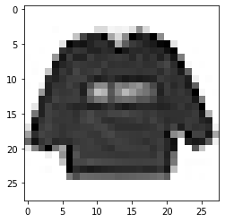

```python
import matplotlib.pyplot as plt

xx = df.iloc[0, 1:].to_numpy().reshape(28, 28)
plt.imshow(xx, cmap="Greys")
```

Visualize the first 36 rows of the dataset and display them as an images to have an example of clothes we will be working with.

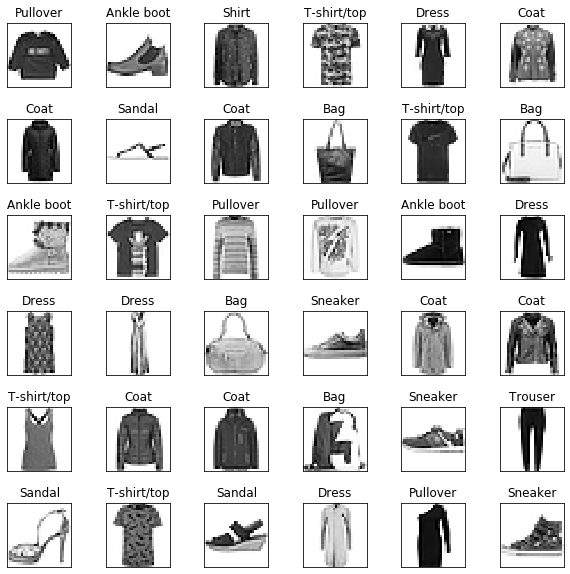

```python
import numpy as np

# How many images to display.
numbers_to_display = 36

# Calculate the number of cells that will hold all the images.
num_cells = np.ceil(np.sqrt(numbers_to_display))

# Make the plot a little bit bigger than default one.
plt.figure(figsize=(10, 10))

# Go through the first images in a training set and plot them.
for plot_index in range(numbers_to_display):
    # Extract image data.
    digit = df[plot_index : plot_index + 1].values
    digit_label = digit[0][0]
    digit_pixels = digit[0][1:]

    # Calculate image size (remember that each picture has square proportions).
    image_size = int(np.sqrt(digit_pixels.shape[0]))

    # Convert image vector into the matrix of pixels.
    frame = digit_pixels.reshape((image_size, image_size))

    # Plot the image matrix.
    plt.subplot(num_cells, num_cells, plot_index + 1)
    plt.imshow(frame, cmap="Greys")
    plt.title(label_map[digit_label])
    plt.tick_params(
        axis="both",
        which="both",
        bottom=False,
        left=False,
        labelbottom=False,
        labelleft=False,
    )

# Plot all subplots.
plt.subplots_adjust(hspace=0.5, wspace=0.5)
plt.show()
```

### Scale features

```python
x = df.iloc[:, 1:].to_numpy()
y = df.iloc[:, 0].to_numpy().flatten()

ss = StandardScaler().fit(x)
x = ss.transform(x)
print(x)
```

```
[[-0.01414355 -0.03192522 -0.09155168 ... -0.16401084 -0.09013093
  -0.0327934 ]
 [-0.01414355 -0.03192522 -0.09155168 ... -0.16401084 -0.09013093
  -0.0327934 ]
 [-0.01414355 -0.03192522 -0.09155168 ... -0.16401084 -0.09013093
  -0.0327934 ]
 ...
 [-0.01414355 -0.03192522 -0.09155168 ... -0.16401084 -0.09013093
  -0.0327934 ]
 [-0.01414355 -0.03192522 -0.09155168 ... -0.16401084 -0.09013093
  -0.0327934 ]
 [-0.01414355 -0.03192522 -0.09155168 ...  2.42966992 -0.09013093
  -0.0327934 ]]
```

### Comparing models using the cross validation method

```python
from sklearn.neural_network import MLPClassifier
from sklearn.tree import DecisionTreeClassifier
from sklearn.ensemble import RandomForestClassifier
from sklearn.ensemble import AdaBoostClassifier
from sklearn.ensemble import GradientBoostingClassifier


model_list["MLP"] = MLPClassifier(
    random_state=random_seed_val, activation="logistic", max_iter=10000
)

model_list["DT"] = DecisionTreeClassifier(
    criterion="entropy", random_state=random_seed_val
)

model_list["RF"] = RandomForestClassifier(
    criterion="entropy", random_state=random_seed_val
)

model_list["AdaBoost"] = AdaBoostClassifier(
    n_estimators=50, random_state=random_seed_val
)

model_list["GBDT"] = GradientBoostingClassifier(
    n_estimators=50, random_state=random_seed_val
)
```

```python
import time

k_fold = 5
results_cv = {}
algo_list = ["MLP", "DT", "RF", "AdaBoost", "GBDT"]

for algo in algo_list:
    a = time.monotonic()
    print(f"Start running {algo}")
    results_cv[algo] = np.mean(cross_val_score(model_list[algo], x, y, cv=k_fold))
    b = time.monotonic()
    print(f"Finish running: {b-a}\n =====\n")
```

```
Start running MLP
Finish running: 53.07800000000134
 =====

Start running DT
Finish running: 8.078000000001339
 =====

Start running RF
Finish running: 22.389999999999418
 =====

Start running AdaBoost
Finish running: 29.875
 =====

Start running GBDT
Finish running: 671.4379999999946
 =====
```

```python
results_cv
```

```
{'MLP': 0.8542,
 'DT': 0.7494,
 'RF': 0.8474,
 'AdaBoost': 0.44000000000000006,
 'GBDT': 0.8294}
```